# *de novo* assembly Day 2

## Identifying differentially expressed genes

There are several methods for estimating transcript abundance in a genome-free manner, and these include alignment-based methods (aligning reads to the transcript assembly) and alignment-free methods (typically examining k-mer abundances in the reads and in the resulting assemblies).

In this section, we will make use of a Trinity helper script to quantify transcript and gene-level abundances of each of our 6 samples using the alignment-free method salmon (Patro et al. 2017).

### Quantification with salmon

```bash
# Write an sbatch script to run salmon for transcript quantification
# Estimated run time: ~ 5 min
# Hints:    - Check the trinity documentation and find a perl helper script that can be used to quantify with salmon
#           - Submit this via sbatch with 4 CPUs, 20G of memory and a 2h hour run time
#           - Ensure that you activate the transcriptomics_bbda conda environment
#           - Do not forget about strand orientation
#           - Use `--gene_trans_map  xxx/Trinity.fasta.gene_trans_map` to quantify on transcript as well as gene level
#           - Add `--prep_reference` to build a target index
...

# Cleanup:
# unfortunately, the --output_dir does not work very well and
# Salmon will generate one output folder per sample in the working dir,
# therefore, use the mv command to generate an organized folder structure
...

# The salmon log file can be used to extract the mapping rate,
# another useful statistic to assess the assembly quality.
# We provide a small helper script for this.
# Use it and check what the mapping rate is
cp /zfs/omics/projects/education/BBDA_transcriptomics/denovo/scripts/parse_salmon.py scripts
python scripts/parse_salmon.py -i logs/salmon_*.err

# With this you have all files for your DEG analysis with DESeq in R
# You can do the analysis on Crunchomics or on your own computer if you prefer to use RStudio
# If you want to do the later you need to transfer the salmon folders,
# assembly, gene to transcript mapping and parsed annotations
# for the downstream analyses to your own computer
scp ...

# Hint: You can use rsync to download and maintain a folder structure
# but have fine-grained control over what you want to access
# Step 1:  -a : archive mode (preserves permissions, timestamps, symlinks)
#         -v : verbose (prints progress)
# Step 2: Keep directory structure but only include specific files
#         --prune-empty-dirs : remove any empty directories from the copy
#         --include='*/'     : include all directories so structure is preserved
#         --include='quant.sf' : include transcript-level quantification files
#         --include='quant.sf.genes' : include gene-level quantification files
#         --exclude='*'      : exclude everything else
rsync -av --prune-empty-dirs \
    --include='*/' \
    --include='quant.sf' \
    --include='quant.sf.genes' \
    --exclude='*' \
    crunchomics:/path/salmon_abund/ results/trinity/salmon_abund/
```

**CautionCode example**

```bash
# Write an sbatch script to run salmon for transcript quantification

sbatch scripts/run_salmon.sh

'''
#!/bin/bash
#SBATCH --job-name=salmon
#SBATCH --output=logs/salmon_%j.out
#SBATCH --error=logs/salmon_%j.err
#SBATCH --cpus-per-task=4
#SBATCH --mem=20G
#SBATCH --time=02:00:00

# Activate conda environment
source ~/.bashrc
conda activate /zfs/omics/projects/education/BBDA_transcriptomics/denovo/envs/trinity_bbda

# Run Salmon
align_and_estimate_abundance.pl \
        --seqType fq \
        --samples_file files/trinity_mapping.txt \
        --transcripts trinity/trinity.Trinity.fasta \
        --SS_lib_type RF \
        --est_method salmon \
        --gene_trans_map trinity/trinity.Trinity.fasta.gene_trans_map \
        --prep_reference \
        --thread_count 4 \
        --output_dir trinity/salmon_abund/
'''

# Cleanup:
mkdir trinity/salmon_abund/
mv treated_rep* trinity/salmon_abund/
mv untreated_rep* trinity/salmon_abund/

# The salmon log file can be used to extract the mapping rate
cp /zfs/omics/projects/education/BBDA_transcriptomics/denovo/scripts/parse_salmon.py scripts
python scripts/parse_salmon.py -i logs/salmon_*.err

# Download the data
# The rsync command will only download the quant files but keep the folder structure intact
scp user@omics-h0.science.uva.nl:/path/trinity.Trinity* results/trinity
scp user@omics-h0.science.uva.nl:/path/annotations/KEGG/sequence_results_best_hit_desc.txt results/annotations/

rsync -av --prune-empty-dirs \
    --include='*/' \
    --include='quant.sf' \
    --include='quant.sf.genes' \
    --exclude='*' \
    user@omics-h0.science.uva.nl:/path/salmon_abund/ results/trinity/salmon_abund/
```

### DEG analysis with DESeq2

After transcriptome assembly and annotation, differential gene expression (DGE) analysis helps us identify genes with significantly different expression levels between experimental conditions. Since you have worked with DESeq2 before, you can use your notes from that tutorial to run the next steps. Briefly, you want to do the following:

1. Load the required libraries (tidyverse, tximport and DESeq2). Note, none of these are installed but you can install them yourself on your personal PC or the HPC with `install.packages("name")`
2. Read in the salmon data with [tximport](https://bioconductor.org/packages/devel/bioc/vignettes/DESeq2/inst/doc/DESeq2.html#transcript-abundance-files-and-tximport-tximeta)
   1. You can use the salmon folder names to make a minimal samples mapping file:

   ```r
   # Get a list of the salmon folder names
   dir <- "results/trinity/salmon_abund"
   folders <- list.dirs(dir, full.names = FALSE, recursive = FALSE)

   # Using the folder names, extract the names of the treatments and build a samples dataframe
   condition <- ifelse(grepl("^treated", folders), "treated", "untreated")

   samples <- data.frame(
   run = folders,
   condition = factor(condition)
   )

   samples
   ```

   2. tximport requires the tx2gene argument to summarize the data on gene level. For this we can use the gene_trans_map from Trinity. However, read the tximport documentation carefully to ensure that the format is correct. Hint: Watch the order of the columns
3. Optional: Read in the annotations and summarize the isoform information on gene level by only selecting the “best” annotation per isform using the highest bit-score. Hint: Beware of ties.
4. Generate a DESeqDataSet object
   1. Ensure that the untreated samples are used as reference level
   2. Optional: Filter low abundance hits. For example, you can require that genes have Y or more samples with counts of X or more
5. Optional: Visualize the data with a PCA. This is a good sanity check to ensure that the replicates cluster as expected.
6. Identify differentially expressed genes. Hint: In the `results()` function, use reasonable cutoffs for alpha and lfcThreshold to focus on “high-confidence” DEGs
7. Add the information from the annotations to the results to be able to quickly screen the list for genes of interest.

**CautionCode example**

### General setup

```r
# Load necessary libraries
library("tidyverse")
library("tximport")
library("DESeq2")
```

### Read in salmon data

```r
# Locate the directory containing the salmon files
dir <- "results/trinity/salmon_abund"
folders <- list.dirs(dir, full.names = FALSE, recursive = FALSE)
folders
```

```
[1] "treated_rep1"   "treated_rep2"   "treated_rep3"   "untreated_rep1"
[5] "untreated_rep2" "untreated_rep3"
```

```r
# Using the folder names:
# Generate a data frame that contains the new sample names, i.e. treatment_rep1,
# and the treatment (treated versus untreated)
condition <- ifelse(grepl("^treated", folders), "treated", "untreated")

samples <- data.frame(
    run = folders,
    condition = factor(condition)
)

samples
```

```
             run condition
1   treated_rep1   treated
2   treated_rep2   treated
3   treated_rep3   treated
4 untreated_rep1 untreated
5 untreated_rep2 untreated
6 untreated_rep3 untreated
```

```r
# Create a named vector that points to the sample files
files <- file.path(dir, samples$run, "quant.sf")
names(files) <- samples$run
files
```

```
                                          treated_rep1
  "results/trinity/salmon_abund/treated_rep1/quant.sf"
                                          treated_rep2
  "results/trinity/salmon_abund/treated_rep2/quant.sf"
                                          treated_rep3
  "results/trinity/salmon_abund/treated_rep3/quant.sf"
                                        untreated_rep1
"results/trinity/salmon_abund/untreated_rep1/quant.sf"
                                        untreated_rep2
"results/trinity/salmon_abund/untreated_rep2/quant.sf"
                                        untreated_rep3
"results/trinity/salmon_abund/untreated_rep3/quant.sf"
```

```r
# For gene-level summarization link the transcript to gene IDs
# For this tximport needs a dataframe with two columns: transcript ID and gene ID
# Trinity provides this file but in the wrong order, so we have to clean it up first
tx2gene <- read_tsv("results/trinity/trinity.Trinity.fasta.gene_trans_map",  col_names = FALSE)
tx2gene <- tx2gene[,c(2,1)]   # reverse the order of the columns
colnames(tx2gene) <- c("transcript", "gene") # add a sensible header
head(tx2gene)
```

```
# A tibble: 6 × 2
  transcript              gene
  <chr>                   <chr>
1 TRINITY_DN8958_c0_g1_i1 TRINITY_DN8958_c0_g1
2 TRINITY_DN8942_c0_g1_i1 TRINITY_DN8942_c0_g1
3 TRINITY_DN8974_c0_g1_i1 TRINITY_DN8974_c0_g1
4 TRINITY_DN8974_c0_g1_i2 TRINITY_DN8974_c0_g1
5 TRINITY_DN8918_c0_g1_i1 TRINITY_DN8918_c0_g1
6 TRINITY_DN8985_c0_g1_i1 TRINITY_DN8985_c0_g1
```

```r
# Read in the files using tximport
txi <- tximport(files, type = "salmon", tx2gene = as.data.frame(tx2gene))
```

### Read in and summarize annotations

```r
# Read in the annotation data
annotations_df <- read_tsv("results/annotations/sequence_results_best_hit_desc.txt")

# Since several genes can consist of more than one transcript, we will now condense the data by gene (by choosing the top hit)
annotations_gene_level <- annotations_df |>
    mutate(
        # Extract gene id by ignoring the _i.* part of the transcript name
        gene = sub("_i.*", "", accession)
    ) |>
    group_by(gene) |>
    arrange(desc(KO_bit_score), KO_e_value) |>
    slice_head(n = 1) |>
    ungroup()
```

### Generate a DESeqDataSet object

```r
# Generate a DESeqDataSet object
dds = DESeqDataSetFromTximport(txi, colData = samples, design = ~condition)

# Remove uninformative columns (optional)
# This step only keeps genes that have Y or more samples with counts of X or more (keep <- rowSums( counts(dds) >= X ) >= Y)
# Choose: Y = 3 because thats the nr of replicates, and 3 a commonly used cutoff
# I used 5 here, since we work with down-sampled data
keep <- rowSums( counts(dds) >= 5 ) >= 3
dds <- dds[keep, ]

# Ensure that untreated samples are seen as the reference level
dds$condition <- relevel(dds$condition, ref = "untreated")
```

### Perform quality assessment

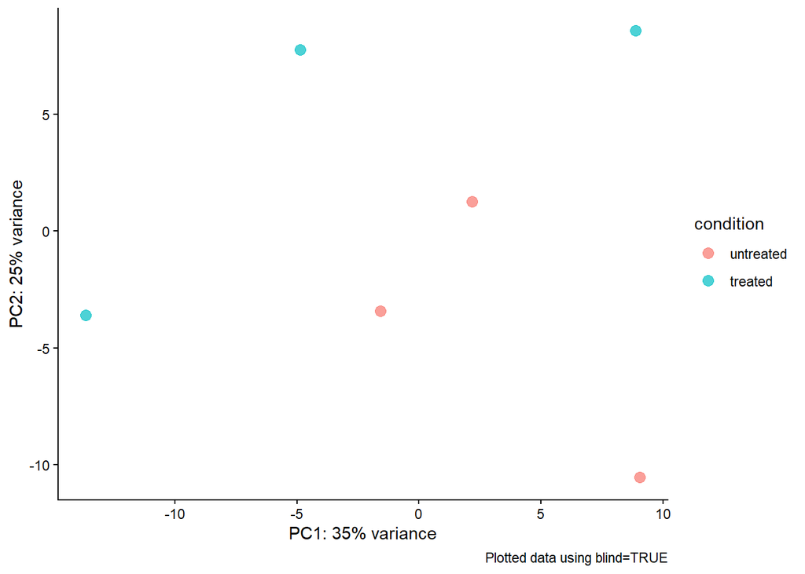

```r
# Perform rlog transformation for explorative data visualization
rld_blindTRUE <- rlog(dds, blind=TRUE)

# Generate a PCA plot
pcaData <- plotPCA(rld_blindTRUE, intgroup= c("condition"), returnData = TRUE)
percentVar <- round(100 * attr(pcaData, "percentVar"))

PCA_plot <-
    ggplot(pcaData, aes(x = PC1, y = PC2)) +
        geom_point(size = 3, aes( color = condition), alpha = 0.7) +
        xlab(paste0("PC1: ", percentVar[1], "% variance")) +
        ylab(paste0("PC2: ", percentVar[2], "% variance")) +
        labs(caption = "Plotted data using blind=TRUE") +
        theme_classic()

PCA_plot
```

### Identify DEGs

```r
# Run DESEQ
dds <- DESeq(dds)

# Extract DEGs
res_table <- results(dds, contrast=c("condition", "treated", "untreated"), alpha = 0.05, lfcThreshold = 0.58)

# Apply log2-shrinkage
res_table_unshrunken <- res_table
res_table <- lfcShrink(dds, contrast=c("condition", "treated", "untreated"), res = res_table, type="ashr")

# Summarize the results
summary(res_table, alpha = 0.05)
```

```
out of 16278 with nonzero total read count
adjusted p-value < 0.05
LFC > 0 (up)       : 58, 0.36%
LFC < 0 (down)     : 2, 0.012%
outliers [1]       : 5, 0.031%
low counts [2]     : 2210, 14%
(mean count < 7)
[1] see 'cooksCutoff' argument of ?results
[2] see 'independentFiltering' argument of ?results
```

```r
# Convert table to tibble
res_table_tb <- res_table |>
    data.frame() |>
    rownames_to_column(var = "gene") |>
    as_tibble()

# Subset DEGs only
res_table_sig <- res_table_tb |>
    filter(padj < 0.05)

# Add annotation info
res_table_sig <- merge(res_table_sig, annotations_gene_level, on = "gene", all.x = TRUE)

# Write to file
write.csv(res_table_sig, "results/trinity/degs.csv", row.names = FALSE, quote = FALSE)
```

**NoteQuestion**

1. How many genes were identified as DEGs. How many genes were up- and down-regulated? Is this comparable to what has been described in the paper?
2. Look at the gene descriptions (based on the KO annotations), what kind of genes are typically differentially expressed? Again, compare this to what has been described in the paper and whether your results are consistent.
   1. Hint: You can upload the KOs of DEGs [here](https://www.genome.jp/kegg/mapper/search.html) to get a quick glimpse at the associated metabolic pathways.
   2. Hint: If you uploaded the KOs to the website above you might see a number of pathways related to medical pathways. You can ignore those because they are not relevant for our study system and they often tend to come up if housekeeping genes, such as ribosomal proteins, show a differential expression.

**TipAnswer**

🔎 **Good to Know**:

**Versions matter**: When running this tutorial I noticed that knowing the version of your software is crucial if you want to repeat the code as this can impact your results. This is what happened to me, when running the code in two different R environments:

[output not shown]

The `filterThreshold` is an automatically calculated cutoff used in DESeq2’s independent filtering. It represents the minimum mean normalized count that a gene should have to be included in multiple testing correction. You can check the used threshold with `metadata(res)$filterThreshold`.

So when writing code:

- always record the package versions in your method section
- use `sessionInfo()` in your R scripts to automatically print all attached packages and package version

## References

Finn, Robert D., Jody Clements, William Arndt, Benjamin L. Miller, Travis J. Wheeler, Fabian Schreiber, Alex Bateman, and Sean R. Eddy. 2015. “HMMER Web Server: 2015 Update.” *Nucleic Acids Research* 43 (W1): W30–38. https://doi.org/10.1093/nar/gkv397.

Haas, BJ. 2025. *TransDecoder/TransDecoder*. TransDecoder. https://github.com/TransDecoder/TransDecoder.

Kanehisa, M. 2000. “KEGG: Kyoto Encyclopedia of Genes and Genomes.” *Nucleic Acids Research* 28 (1): 27–30. https://doi.org/10.1093/nar/28.1.27.

Patro, Rob, Geet Duggal, Michael I Love, Rafael A Irizarry, and Carl Kingsford. 2017. “Salmon Provides Fast and Bias-Aware Quantification of Transcript Expression.” *Nature Methods* 14 (4): 417–19. https://doi.org/10.1038/nmeth.4197.

Simão, Felipe A., Robert M. Waterhouse, Panagiotis Ioannidis, Evgenia V. Kriventseva, and Evgeny M. Zdobnov. 2015. “BUSCO: Assessing Genome Assembly and Annotation Completeness with Single-Copy Orthologs.” *Bioinformatics* 31 (19): 3210–12. https://doi.org/10.1093/bioinformatics/btv351.